# A3: Incarceration

### Natnael Tekie, 2122558

### Introduction

> In the United States, the issue of mass incarceration has been a long-standing and complex problem, disproportionately affecting people of color, particularly Black Americans. The racial disparities in incarceration rates are rooted in a combination of historical and contemporary factors, including systemic racism, discriminatory policies, and socioeconomic inequalities. To better understand and address this pressing issue, it is crucial to analyze incarceration trends and patterns across different demographic groups and geographic regions. For this analysis, I have chosen to focus on the “total_jail_pop” variable, which represents the yearly jail population for each county or state. This variable is particularly relevant as it provides insights into the number of individuals detained in local jails, which often serve as entry points into the broader criminal justice system. By examining the jail population data, we can shed light on potential disparities and inequalities at the local level, which can inform policy decisions and reform efforts.

### Summary Information

> Based on the analysis of the “total_jail_pop” variable, the following summary statistics provide key insights into the jail population trends in the United States:

[output not shown]

> These summary statistics highlight the wide range of jail population values across different regions, as well as the overall upward trend in incarceration rates over recent decades.

### The Dataset

**Who collected the data?**

```
The data used in this analysis was collected by the Vera Institute of Justice,
a nonprofit organization dedicated to researching and advancing solutions to the challenges
faced by the criminal justice system
```

**How was the data collected or generated?**

```
The incarceration trends dataset was generated through a comprehensive effort to compile
and standardize data from various sources, including the Bureau of Justice Statistics,
the Census Bureau, and state-level departments of corrections.
```

**Why was the data collected?**

```
This data was collected not only to provide a comprehensive and reliable source of information
on incarceration rates and trends across the United States but also to
Facilitate research, inform policymakers, and raise awareness about the
issues surrounding mass incarceration.
```

> The dataset contains 153811 rows

> The dataset has a total of 28 columns.

**What, if any, ethical questions or questions of power do you need to consider when working with this data?**

```
The criminal justice system has historically been marked by racial disparities and systemic biases,
which can be reflected in the data. Additionally, the collection and representation of data can be
influenced by various factors, including the methods used, the sources of information, and the
perspectives of those involved in the data collection process.
```

**What are possible limitations or problems with this data? (at least 200 words)**

[output not shown]

### Trends Over Time Chart

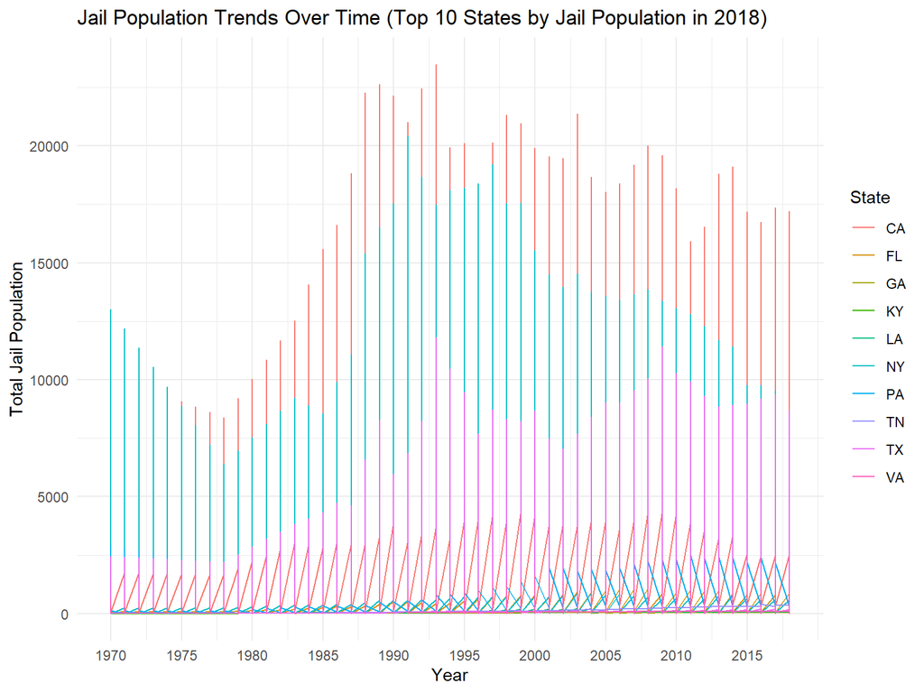

> The chart above displays the trends in jail population over time for the top 10 states with the highest jail populations up to 2018. This comparison allows us to visualize the variations in incarceration rates across different regions and identify potential patterns or outliers.

##### Several patterns emerge from this chart:

[output not shown]

These findings highlight the significant variations in incarceration rates across different states and the need for further analysis to understand the underlying factors contributing to these disparities.

### Variable Comparison Chart

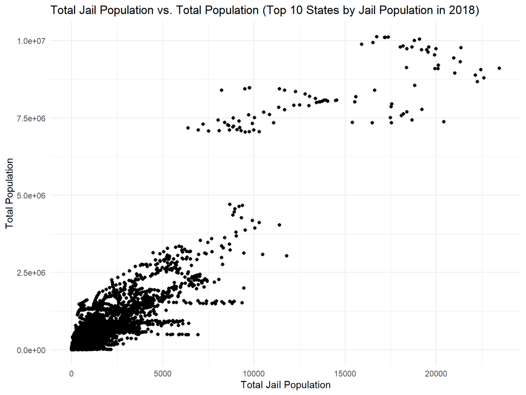

> The chart displays a scatter plot comparing the total jail population and the total population for the top 10 states by jail population in 2018. This comparison allows us to explore the relationship between incarceration rates and population size across different states.

**Several patterns emerge from this scatter plot:**

```
-There is a positive correlation between the total jail population and the total population.
States with larger overall populations tend to have higher jail populations.
-However, the relationship is not entirely linear, as there is a considerable spread in the data points.
This suggests that factors beyond just population size influence incarceration rates.
```

### Map

[figure not shown]

#### Several key observations can be made from this map

[output not shown]